# Introducing Signals and Systems

An annotatable copy of the full notes for this presentation are to be found in the *_Content Library* of the **OneNote Class Notebook** for this class. You can also view the notes for this presentation as a webpage ([HTML](http://nbviewer.ipython.org/github/cpjobling/EG-247-Resources/blob/master/introduction/Introduction.ipynb)) and as a downloadable [PDF file](http://cpjobling.github.io/EG-247-Resources/introduction/Introduction.pdf).

## Signals and Systems for Dummies

Signals and Systems for Dummies (**SS4D**) provides a useful introduction to the topics that will be covered in this module and it is in the Reading List as a *recommended text*. I have based this presentation on Chapter 1 which is available as a [downloadable PDF](http://eu.dummies.com/store/product/Signals-and-Systems-For-Dummies.productCd-111847581X.html) from the publishers.

You should read Chapter 1 of SS4D in conjunction with the notes for this presentation.

## Agenda

- Continuous-time signals
- Continuous-time systems
- Discrete-time signals
- Discrete-time systems
- Signal Classifications
- Domains for Signals
- Systems Thinking and Systems Design

These will be illustrated with computation in *Wolfram|Alpha*, *Matlab*, *Simulink*.

## Continuous-time signals

Continuous signals are represented mathematically by functions which vary continuously with time.

Sinusoidal signals (e.g. AC) are pretty fundamental in electrical engineering. The mathematical model of a sinusoidal signal is:

$$x(t) = A \cos (2\pi f_0 t - \phi).$$

**Without talking to your anyone**, match each of the symbols to its definition

| Symbol | Definition |
| --- | --- |
| $A$ | Phase in radians |
| $f_0$ | Frequency in Hz |
| $\phi$ | Amplitude |
| $2\pi f_0$ | Frequency in rad/s |

#### -> Open Poll

### Gaining insight using computers

To help us answer these questions, let's use our Mathematical tools to plot a signal like this and explore it. The example we will use is from *Signals and Systems for Dummies* (SS4D: page 12):

$$3\cos(2\pi\cdot 2t - 3\pi/4)$$

### Wolfram|Alpha

Here's the link: http://www.wolframalpha.com

Paste this into the search box

```
plot 3 cos(2 pi 2 t - 3 pi/4)
```

### Matlab

In Matlab we would need to tackle this by breaking down the steps.

Define `t`

```matlab
t = linspace(0, 1, 100);
```

Define `x`

```matlab
x = 3 * cos(2*pi*2*t - 3*pi/4);
```

Plot result and label plot

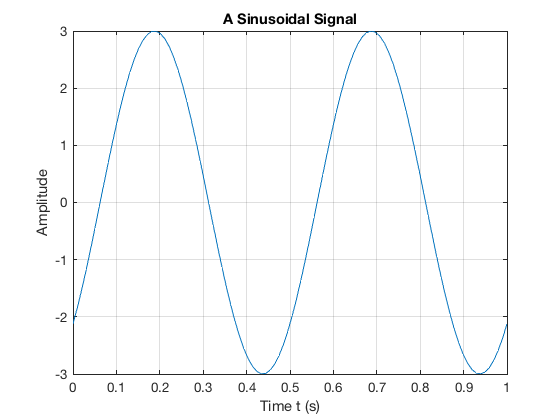

```matlab
plot(t,x)
title('A Sinusoidal Signal')
xlabel('Time t (s)')
ylabel('Amplitude')
grid
```

### Returning to the Question

Sinusoidal signals (e.g. AC) are pretty fundamental in electrical engineering. The mathematical model of a sinusoidal signal is:

$$x(t) = A \cos (2\pi f_0 t - \phi).$$

Using the insight just gained by exploring this function with a computer, try matching each of the symbols to its definition again.

**This time you may confer!**!

| Symbol | Definition |
| --- | --- |
| $A$ | Phase in radians |
| $f_0$ | Frequency in Hz |
| $\phi$ | Amplitude |
| $2\pi f_0$ | Frequency in rad/s |

### Supplementary question

What is the period of the waveform in seconds?

1. $2\pi$
2. $f_0$
3. $t$
4. $1/f_0$
5. $2\pi/f_0$

#### -> Open poll

## Continuous-time Systems

Systems operate on signals. In mathematical terms, a *system* is a function or an *operator*, $H\{\}$ that maps the input signal $x(t)$ to an output signal $y(t)$.

Mathematically we would write this:

$$y(t) = H\{x(t)\}.$$

### Example

An example of a continuous-time system is an electronic amplifier with a gain of 5 and level shift of 2: $y(t) = H\{x(t)\} = 5x(t) + 2$.

In this course, we will model such systems as block diagram models in Simulink.

### Block diagram model in Simulink

[figure not shown]

The Similink code can be downloaded from this file gain_level_shift.slx.

## Demonstration

If the input to this system is replaced with a sinewave $x(t)=\sin(t)$ and the output with a scope, what do you think the output will be?

If you get a chance, try this in youself in Matlab and copy the result into your copy of these notes.

```matlab
open gain_level_shift
```

## Discrete-time Signals

Disrete-time signals are a function of a time index $n$. A discrete-time signal $x[n]$, unlike a continuous-time signal $x(t)$, is only defined at integer values of the independent variable $n$. This means that the signal is only active at specific periods of time. Discrete-time signals can be stored in computer memory.

### Example

Consider the following simple signal, a pulse sequence:$$y[n] = \left\{ {\begin{array}{*{20}{c}} {5,\;0 \le n < 10}\\ {0,\;{\rm{otherwise}}\quad \;} \end{array}} \right.$$ We can plot this in Matlab as a *stem plot*

## Procedure

Define function and save as y.m.

```matlab
open y
```

```matlab
%% Define sample points
n = -15:18;
%% Make space for the signal
xn = zeros(size(n));

%% Compute the signal x[n]
for i = 1:length(xn)
    xn(i) = y(n(i));
end
```

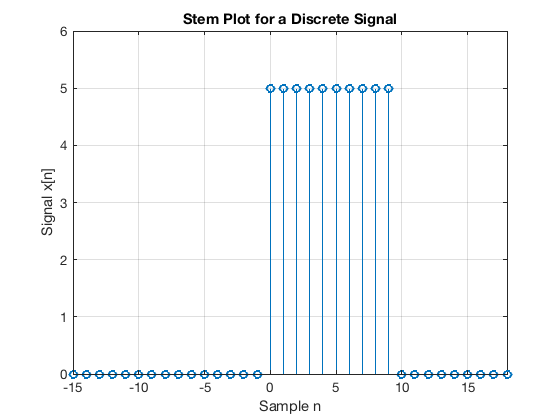

```matlab
%% Plot the result
stem(n,xn)
axis([-15, 18, 0, 6])
title('Stem Plot for a Discrete Signal')
xlabel('Sample n')
ylabel('Signal x[n]')
grid
```

### Exercise

Draw a digital signal that represents your student number in some way. For example if your number was 765443, then you could generate a signal for which $x[n] = 0$ when $n < 7$, then $x[n] = 7$ for $7$ periods, then $x[n] = 6$ for the next 6 periods, $x[n] = 5$ for 5 periods, and so on. The signal should return to 0 when the last digit has been transmitted.

To plot this on a computer you would need to transcribe $x[n]$ into an array and then use the stem plot to plot the data. You could just create the array by hand, but you could also create a Matlab function if you would like a challenge.

## Discrete-time Systems

A discrete-time system, like its continuous-time counterpart, is a function, $H\{\}$, that maps the input $x[n]$￼ ￼to the output $y[n] = H\{x[n]\}$. An example of a discrete-time system is the *two-tap* filter:

$$y[n] = H\{x[n]\} = \frac{3}{4}x[n] + \frac{1}{4}x[n-1]$$

The term *tap* denotes that output at time instant $n$ is formed from two time instants of the input, $n$ and $n – 1$. Check out a block diagram of a two-tap filter system:

[figure not shown]

This system is available as a Simulink model discrete_system.slx

```matlab
open discrete_system
```

## Signal Classifications

### Periodic

Signals that repeat over and over are said to be *periodic*. In mathematical terms, a signal is periodic if:

- *Continuous signal* $x(t + T) = x(t)$
- *Discrete signal* $x[n + N] = x[n]$

￼￼￼￼￼￼￼￼￼￼￼￼￼￼￼￼￼￼￼￼￼￼￼￼￼￼￼￼￼￼￼￼￼￼￼￼￼￼￼￼￼￼￼￼￼￼￼￼￼￼￼￼￼￼The smallest $T$ or $N$ for which the equality holds is the *signal period*.

#### Square Wave

This code generates a square wave.

```matlab
%% A Periodic signal (square wave)
t = linspace(0, 1, 500);
x = square(2 * pi * 5 * t);
```

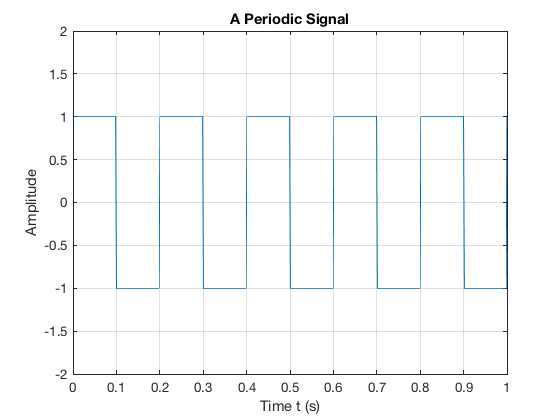

```matlab
plot(t, x);
ylim([-2, 2]);
grid()
title('A Periodic Signal')
xlabel('Time t (s)')
ylabel('Amplitude')
```

$T = $?

### Aperiodic

Signals that are *deterministic* (completely determined functions of time) but not periodic are known as *aperiodic*. Point of view matters. If a signal occurs infrequently, you may view it as aperiodic.

This is how we generate an aperiodic rectangular pulse of duration $\tau$ in Matlab:

See aperiodic.m

```matlab
%% An aperiodic function
tau = 1;
x = linspace(-1,5,1000);
y = rectangularPulse(0,tau,x);
```

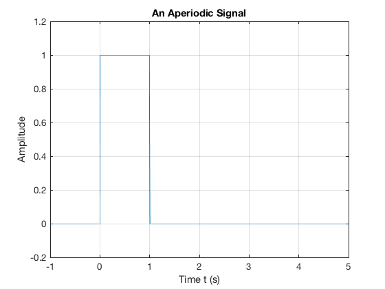

```matlab
plot(x,y)
ylim([-0.2,1.2])
grid
title('An Aperiodic Signal')
xlabel('Time t (s)')
ylabel('Amplitude')
```

### Random

A signal is random if one or more signal attributes takes on unpredictable values in a probability sense. ￼￼￼￼￼￼￼￼￼￼￼￼￼￼￼￼￼￼￼￼￼ Engineers working with communication receivers are concerned with random signals, especially noise.

See: random.m

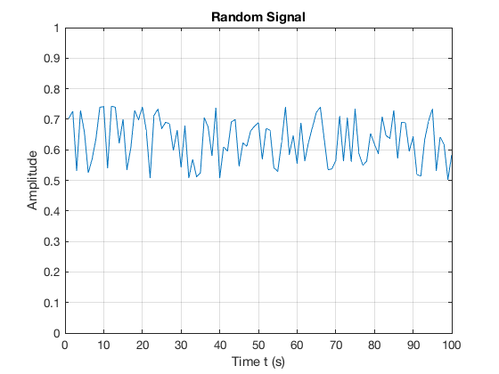

```matlab
%% Plot a Random Signal
plot(0.5 + 0.25 * rand(100,1))
ylim([0,1])
grid
title('Random Signal')
xlabel('Time t (s)')
ylabel('Amplitude')
```

## Domains for Signals and Systems

Most of the signals we encounter on a daily basis reside in the time domain. They’re functions of independent variable $t$ or $n$. But sometimes when you’re working with continuous-time signals, you may need to transform away from the time domain ($t$) to another domain.

### Domain Quiz

A domain which is used in the analysis of signals and the design of systems is represented by complex numbers of the form:

$$\sigma + j\omega$$

**Without conferring**, tell me what domain is this?

#### -> Open Poll

### Now discuss your answer with your peers

### Domain Quiz (again)

A domain which is used in the analysis of signals and the design of systems is represented by complex numbers of the form:

$$\sigma + j\omega$$

Tell me what domain is this?

#### -> Open Poll

### Other Domains you will encounter

The most commnly used domains used when analysing continuous time signals are the frequency domain ($f$ or $\omega$) or the Laplace $s$-domain ($s$).

Similarly, for discrete-time signals, you may need to transform from the discrete-time domain ($n$) to the frequency domain ($\hat{\omega}$￼) or the z-domain ($z$).

This section briefly introduces the world of signals and systems in the frequency, s-, and z-domains. More on these domains will follow.

Consider the sum of a two-sinusoids signal $$x(t) = \underbrace {A_1\cos(2\pi f_1 t)}_{s_1} + \underbrace {A_2\cos(2\pi f_2 t)}_{s_2}$$

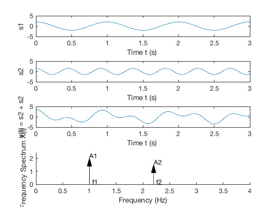

```matlab
two_sines
```

### Fourier Transform

We use the *Fourier transform* to move away from the time domain and into the frequency domain. To get back to the time domain, use the *inverse Fourier transform*. We will found out more about these transforms in this module.

### Laplace and Z-Transform Domains

From the time domain to the frequency domain, only one independent variable, $t \to f$, exists. When a signal is transformed to the *s*-domain, it becomes a function of a complex variable ￼$s=\sigma + j\omega$. The two variables (real and imaginary parts) describe a location in the *s*-plane.

In addition to visualization properties, the *s*-domain reduces differential equation solving to algebraic manipulation. For discrete-time signals, the *z*-transform accomplishes the same thing, except differential equations are replaced by difference equations.

## Systems Thinking and Systems Design

See section **Testing Product Concepts with Behavioral Level Modeling** from Chapter 1 of [SS4D](http://www.dummies.com/store/product/Signals-and-Systems-For-Dummies.productCd-111847581X.html) (pages 18--20) and add some notes to summarize this for yourself.

- We will use *behavioural modelling*
- We will rely on *abstraction*
- We work *top-down*
- We make use of *mathematics* and *mathematical software*.

## Familiar Signals and Systems

See pages 21-23 of the free sample (Chapter 1) of [SS4D](http://www.dummies.com/store/product/Signals-and-Systems-For-Dummies.productCd-111847581X.html) for notes and details.

### Challenge

I used the examples from **Signals and Systems for Dummies** to seed this Padlet collection Examples of Signals and Systems.

[figure not shown]

Can you add to it?

## Concluding Example: Some Basic Signal Operations

Consider a signal

$$x = f(t) = \left\{ {\begin{array}{*{20}{c}} {0\;:\;t < - 1}\\ {t + 1\;:\; - 1 \le t \le 1}\\ {0\;:\;t > 1} \end{array}} \right.$$

Sketch this signal.

### Problem

Think about the effect on this signal of applying the following basic signal operations:

- $2 f(t)$
- $0.5 f(t)$
- $f(2t)$
- $f(0.5 t)$
- $-f(t)$
- $f(-t)$
- $-f(-t)$
- $f(t - 1)$
- $f(t + 1)$
- $-2f(-t+2)$

We will work through these after the break together then you will do some exercises based on [Chapter 1 of Karris](http://site.ebrary.com/lib/swansea/reader.action?docID=10547416&ppg=17).